# KNN_Regression

This is an assignment for my thinkful data science course. Raj Prasad May 2019

[html version](https://daddyprasad5.github.io/KNN_Regression.html) - with all the code hidden away for a quick read

[jupyter notebook version](https://github.com/daddyprasad5/thinkful/blob/master/KNN_Regression.ipynb) - with all the code exposed in an interactive notebook

```python
import numpy as np
import pandas as pd
from sklearn import linear_model
from sklearn.linear_model import LinearRegression, LassoCV, RidgeCV, ElasticNetCV
import matplotlib.pyplot as plt
from sqlalchemy import create_engine
import statsmodels.api as sm
from statsmodels.tools.eval_measures import mse, rmse
import seaborn as sns
from scipy.stats import zscore
from scipy.stats.mstats import winsorize
import scipy.stats as stats
from sklearn.model_selection import train_test_split
from sklearn.metrics import mean_absolute_error
from IPython.display import display, HTML
%matplotlib inline

music = pd.DataFrame()
music['duration'] = [184, 134, 243, 186, 122, 197, 294, 382, 102, 264,
                     205, 110, 307, 110, 397, 153, 190, 192, 210, 403,
                     164, 198, 204, 253, 234, 190, 182, 401, 376, 102]
music['loudness'] = [18, 34, 43, 36, 22, 9, 29, 22, 10, 24,
                     20, 10, 17, 51, 7, 13, 19, 12, 21, 22,
                     16, 18, 4, 23, 34, 19, 14, 11, 37, 42]
music['bpm'] = [ 105, 90, 78, 75, 120, 110, 80, 100, 105, 60,
                  70, 105, 95, 70, 90, 105, 70, 75, 102, 100,
                  100, 95, 90, 80, 90, 80, 100, 105, 70, 65]
```

# KNN Regression

So far we've introduced KNN as a classifier, meaning it assigns observations to categories or assigns probabilities to the various categories. However, KNN is also a reasonable algorithm for regression. It's a simple extension of what we've learned before and just as easy to implement.

## Everything's the Same

Switching KNN to a regression is a simple process. In our previous models, each of the $k$ oberservations voted for a *category*. As a regression they vote instead for a *value*. Then instead of taking the most popular response, the algorithm averages all of the votes. If you have weights you perform a weighted average.

It's really that simple.

Let's go over a quick example just to confirm your understanding.

Let's stick with the world of music. Instead of trying to classify songs as rock or jazz, lets take the same data with an additional column: beats per minute, or BPM. Can we train our model to predict BPM?

First let's try to predict just in terms of loudness, as this will be easier to represent graphically.

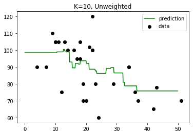

```python
from sklearn import neighbors

# Build our model.
knn = neighbors.KNeighborsRegressor(n_neighbors=10)
X = pd.DataFrame(music.loudness)
Y = music.bpm
knn.fit(X, Y)

# Set up our prediction line.
T = np.arange(0, 50, 0.1)[:, np.newaxis]

# Trailing underscores are a common convention for a prediction.
Y_ = knn.predict(T)

plt.scatter(X, Y, c='k', label='data')
plt.plot(T, Y_, c='g', label='prediction')
plt.legend()
plt.title('K=10, Unweighted')
plt.show()
```

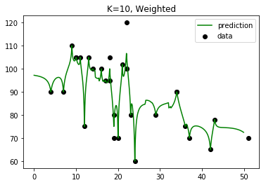

```python
# Run the same model, this time with weights.
knn_w = neighbors.KNeighborsRegressor(n_neighbors=10, weights='distance')
X = pd.DataFrame(music.loudness)
Y = music.bpm
knn_w.fit(X, Y)

# Set up our prediction line.
T = np.arange(0, 50, 0.1)[:, np.newaxis]

Y_ = knn_w.predict(T)

plt.scatter(X, Y, c='k', label='data')
plt.plot(T, Y_, c='g', label='prediction')
plt.legend()
plt.title('K=10, Weighted')
plt.show()
```

Notice how it seems like the weighted model grossly overfits to points. It is interesting that it oscillates around the datapoints. This is because the decay in weight happens so quickly.

## Validating KNN

Now validating KNN, whether a regression or a classifier, is pretty much exactly the same as evaluating other classifiers or regression. Cross validation is still tremendously valuable. You can do holdouts. You even still get an $R^2$ value for the regression.

Why don't we validate that overfitting of the previous model with some k-fold cross validation? The test statistic given by this model is $R^2$, which measures the same as in linear regression.

```python
from sklearn.model_selection import cross_val_score
score = cross_val_score(knn, X, Y, cv=5)
print("Unweighted Accuracy: %0.2f (+/- %0.2f)" % (score.mean(), score.std() * 2))
score_w = cross_val_score(knn_w, X, Y, cv=5)
print("Weighted Accuracy: %0.2f (+/- %0.2f)" % (score_w.mean(), score_w.std() * 2))
```

```
Unweighted Accuracy: -0.18 (+/- 0.66)
Weighted Accuracy: 0.11 (+/- 0.94)
```

First let me state that these two models are fantastically awful. There doesn't seem to be much of a relationship. It's all very poor. However the increased variance in the weighted model is interesting.

Why don't you add the other feature and mess around with $k$ and weighting to see if you can do any better than we've done so far?

```python
#for reference later...
#sorted(sklearn.metrics.SCORERS.keys())
```

```python
## Your model here.
def predict_and_evaluate(models, model_names, X_train, y_train, X_test):

    i = 0
    best_alpha = []
    r_squared_train = []
    r_squared_test = []
    mean_abs_err = []
    mean_sq_err = []
    rt_mean_sq_err = []
    mean_abs_perc_err = []

    for model in models:
        y_preds_train = model.predict(X_train)
        y_preds_test = model.predict(X_test)

        if (getattr(model, "alpha_", False)):
            best_alpha.append(model.alpha_)
        else:
            best_alpha.append(None)
        r_squared_train.append(model.score(X_train, y_train))
        r_squared_test.append(model.score(X_test, y_test))
        mean_abs_err.append(mean_absolute_error(y_test, y_preds_test))
        mean_sq_err.append(mse(y_test, y_preds_test))
        rt_mean_sq_err.append(rmse(y_test, y_preds_test))
        mean_abs_perc_err.append(np.mean(np.abs((y_test - y_preds_test) / y_test)) * 100)
        i += 1
    summary = pd.DataFrame({"best_alpha": best_alpha, "r_squared_train": r_squared_train,
                        "r_squared_test": r_squared_test, "mean_abs_err": mean_abs_err,
                        "mean_sq_err": mean_sq_err, "rt_mean_sq_err": rt_mean_sq_err,
                        "mean_abs_perc_err": mean_abs_perc_err})
    summary.index = model_names
    return summary

X = pd.DataFrame(music.loudness)
Y = music.bpm
X_train, X_test, y_train, y_test = train_test_split(X, Y, test_size = 0.2, random_state = 465)

print("single predictor at various k without weighted distance")

models = []
model_names = []
for k in range(1, 11):
    model = neighbors.KNeighborsRegressor(n_neighbors=k)
    model.fit(X_train, y_train)
    models.append(model)
    model_names.append("k={}".format(k))
display(predict_and_evaluate(models,model_names, X_train, y_train, X_test))

print("single predictor at various k with weighted distance")

models = []
model_names = []
for k in range(1, 11):
    model = neighbors.KNeighborsRegressor(n_neighbors=k, weights='distance')
    model.fit(X_train, y_train)
    models.append(model)
    model_names.append("k={}".format(k))

display(predict_and_evaluate(models,model_names, X_train, y_train, X_test))

#now add the 2nd predictor and re-run for different k values
X = pd.DataFrame({
    'loudness': music.loudness,
    'duration': music.duration
})
X_train, X_test, y_train, y_test = train_test_split(X, Y, test_size = 0.2, random_state = 465)

print("two predictors at various k without weighted distance")

models = []
model_names = []
for k in range(1, 11):
    model = neighbors.KNeighborsRegressor(n_neighbors=k)
    model.fit(X_train, y_train)
    models.append(model)
    model_names.append("k={}".format(k))
display(predict_and_evaluate(models,model_names, X_train, y_train, X_test))

print("two predictors at various k with weighted distance")

models = []
model_names = []
for k in range(1, 11):
    model = neighbors.KNeighborsRegressor(n_neighbors=k, weights='distance')
    model.fit(X_train, y_train)
    models.append(model)
    model_names.append("k={}".format(k))

display(predict_and_evaluate(models,model_names, X_train, y_train, X_test))
```

```
single predictor at various k without weighted distance
```

|  | best_alpha | r_squared_train | r_squared_test | mean_abs_err | mean_sq_err | rt_mean_sq_err | mean_abs_perc_err |
| --- | --- | --- | --- | --- | --- | --- | --- |
| k=1 | None | 0.980342 | -0.511568 | 18.333333 | 408.333333 | 20.207259 | 19.087302 |
| k=2 | None | 0.714712 | 0.537275 | 8.333333 | 125.000000 | 11.180340 | 8.015873 |
| k=3 | None | 0.597511 | 0.496898 | 10.166667 | 135.907407 | 11.657933 | 10.899471 |
| k=4 | None | 0.441943 | 0.131889 | 12.708333 | 234.510417 | 15.313733 | 13.516865 |
| k=5 | None | 0.324461 | -0.098250 | 13.733333 | 296.680000 | 17.224401 | 14.460317 |
| k=6 | None | 0.241563 | -0.172956 | 13.944444 | 316.861111 | 17.800593 | 14.669312 |
| k=7 | None | 0.317787 | -0.072275 | 13.452381 | 289.663265 | 17.019497 | 14.469104 |
| k=8 | None | 0.269250 | -0.051118 | 13.125000 | 283.947917 | 16.850754 | 14.263889 |
| k=9 | None | 0.332663 | 0.076904 | 12.685185 | 249.364198 | 15.791270 | 13.518959 |
| k=10 | None | 0.333564 | 0.048385 | 13.250000 | 257.068333 | 16.033351 | 13.975595 |

```
single predictor at various k with weighted distance
```

|  | best_alpha | r_squared_train | r_squared_test | mean_abs_err | mean_sq_err | rt_mean_sq_err | mean_abs_perc_err |
| --- | --- | --- | --- | --- | --- | --- | --- |
| k=1 | None | 0.980342 | -0.511568 | 18.333333 | 408.333333 | 20.207259 | 19.087302 |
| k=2 | None | 0.990171 | 0.338749 | 10.777778 | 178.629630 | 13.365240 | 10.777778 |
| k=3 | None | 0.990171 | 0.424210 | 11.040765 | 155.543160 | 12.471694 | 11.347403 |
| k=4 | None | 0.990171 | 0.470502 | 10.940746 | 143.037873 | 11.959844 | 11.358633 |
| k=5 | None | 0.990171 | 0.491623 | 10.680837 | 137.332281 | 11.718886 | 11.033559 |
| k=6 | None | 0.990171 | 0.507562 | 10.555736 | 133.026648 | 11.533718 | 10.903773 |
| k=7 | None | 0.990171 | 0.527208 | 10.231710 | 127.719530 | 11.301307 | 10.621692 |
| k=8 | None | 0.990171 | 0.538852 | 9.934316 | 124.574120 | 11.161278 | 10.338470 |
| k=9 | None | 0.990171 | 0.530427 | 10.122728 | 126.850015 | 11.262771 | 10.509209 |
| k=10 | None | 0.990171 | 0.515901 | 10.436205 | 130.774052 | 11.435648 | 10.831920 |

```
two predictors at various k without weighted distance
```

|  | best_alpha | r_squared_train | r_squared_test | mean_abs_err | mean_sq_err | rt_mean_sq_err | mean_abs_perc_err |
| --- | --- | --- | --- | --- | --- | --- | --- |
| k=1 | None | 1.000000 | -0.033419 | 14.166667 | 279.166667 | 16.708281 | 14.761905 |
| k=2 | None | 0.479797 | 0.255784 | 12.083333 | 201.041667 | 14.178916 | 13.214286 |
| k=3 | None | 0.285755 | 0.242913 | 13.444444 | 204.518519 | 14.300997 | 14.140212 |
| k=4 | None | 0.161078 | -0.118985 | 15.291667 | 302.281250 | 17.386237 | 15.818452 |
| k=5 | None | 0.046149 | -0.352391 | 16.000000 | 365.333333 | 19.113695 | 16.650794 |
| k=6 | None | 0.107718 | -0.076692 | 14.305556 | 290.856481 | 17.054515 | 14.708995 |
| k=7 | None | 0.091434 | -0.097319 | 14.523810 | 296.428571 | 17.217101 | 14.807256 |
| k=8 | None | 0.041348 | -0.204810 | 15.562500 | 325.466146 | 18.040680 | 16.025546 |
| k=9 | None | 0.034469 | -0.218798 | 15.462963 | 329.244856 | 18.145106 | 15.963845 |
| k=10 | None | 0.033529 | -0.182830 | 15.550000 | 319.528333 | 17.875355 | 16.187302 |

```
two predictors at various k with weighted distance
```

|  | best_alpha | r_squared_train | r_squared_test | mean_abs_err | mean_sq_err | rt_mean_sq_err | mean_abs_perc_err |
| --- | --- | --- | --- | --- | --- | --- | --- |
| k=1 | None | 1.0 | -0.033419 | 14.166667 | 279.166667 | 16.708281 | 14.761905 |
| k=2 | None | 1.0 | 0.499514 | 9.874172 | 135.200739 | 11.627585 | 10.315809 |
| k=3 | None | 1.0 | 0.419648 | 11.777351 | 156.775532 | 12.521004 | 12.153926 |
| k=4 | None | 1.0 | 0.154081 | 13.373609 | 228.515720 | 15.116736 | 13.508810 |
| k=5 | None | 1.0 | 0.069170 | 13.155569 | 251.453329 | 15.857280 | 13.058624 |
| k=6 | None | 1.0 | 0.156284 | 12.758576 | 227.920446 | 15.097034 | 12.730273 |
| k=7 | None | 1.0 | 0.158560 | 12.580447 | 227.305696 | 15.076661 | 12.502822 |
| k=8 | None | 1.0 | 0.124191 | 12.727469 | 236.590147 | 15.381487 | 12.588200 |
| k=9 | None | 1.0 | 0.124221 | 12.379726 | 236.581896 | 15.381219 | 12.186540 |
| k=10 | None | 1.0 | 0.144248 | 12.064572 | 231.171788 | 15.204335 | 11.836962 |